# Project 2 - First Phase

Ziad Al Bkhetan, Neven Piculjan, Naveen Mupparapu

December 10, 2015

# Internet of Things - Introduction

In the first phase we should characterize types of interactions with different machines (exploratory analysis). We tried to answer following questions:

- What is the average (or distribution) time of interaction with a given machine
- Is there a relation between the duration of an interaction and variables like weekday or hour
- Other statistics

We Assumed That the visit is the duration between Enterance and Leaving Activity for the same visitor in the same station.

We prepared a dataset full of all needed information, then we used grouping function to group the data as we want.

# Data Loading And Preparation

In this step we will prepare the data set to start analysis phase, we assumed that the maybe the dataset is not sorted, so we sort it based on the visitor and date, which makes stations interactions detection easier.  
in this report we worked in a smaller dataset to make the performance faster.

```r
library(tidyr)
library(dplyr)
library(ggplot2)

load('D:/MSc Computer science and informatics/3rd semester/Data Mining - Advances/Lab Projects/Project 2/newSmallLogs.rda')

# Sort the data based on Visitors and Date
index <- with(mydata, order(visitor, date))
orderedData <-mydata[index, ]
```

# Prepare The Final DataSet

in this step we will fetch all needed data for analysis and visualization, and the most important for us are: Visitor ID, Station, Consumed Time, Day, and Hour.  
we loop over the data set and try to find the visits between Entrance and Leaving for the same visitor and same station.

```r
stations_time_lst  <- c()
stations_count_lst <- c()
stations_visit_time_lst <- c()
matRes <- NULL

for (i in 2:nrow(orderedData))
{
  if ((orderedData[i, 3] == orderedData[i - 1, 3]) & (as.character(orderedData[i, 2]) == as.character(orderedData[i - 1, 2])) & (as.character(orderedData[i, 4]) == 'Leaving') & (as.character(orderedData[i - 1, 4]) == 'Entering'))
  {
    if (length(stations_count_lst) == 0)
    {
      tim <- difftime(orderedData[i, 1], orderedData[i - 1, 1],  units = "secs")
      stations_count_lst[as.character(orderedData[i, 2])] <- 1
      stations_time_lst [as.character(orderedData[i, 2])] <- tim
      matRes <- matrix(nrow=1, ncol=5)
      colnames(matRes) <- c('Station', 'Visitor', 'Cons_time', 'WDay', 'THour')
      matRes[1, 1] = as.character(orderedData[i, 2])
      matRes[1, 2] = orderedData[i, 3]
      matRes[1, 3] = as.numeric(tim)
      matRes[1, 4] = as.POSIXlt(orderedData[i - 1, 1])$wday
      matRes[1, 5] = as.POSIXlt(orderedData[i - 1, 1])$hour
    }
    else if (is.na(stations_count_lst[as.character(orderedData[i, 2])]))
        {
          tim <- difftime(orderedData[i, 1], orderedData[i - 1, 1],  units = "secs")
          stations_count_lst[as.character(orderedData[i, 2])] <- 1
          stations_time_lst [as.character(orderedData[i, 2])] <- tim
          matRes <- rbind(matRes, c(as.character(orderedData[i, 2]), orderedData[i, 3], as.numeric(tim), as.POSIXlt(orderedData[i - 1, 1])$wday, as.POSIXlt(orderedData[i - 1, 1])$hour ))
        }
        else
        {
          tim <- difftime(orderedData[i, 1], orderedData[i - 1, 1],  units = "secs")
          stations_count_lst[as.character(orderedData[i, 2])] <- stations_count_lst[as.character(orderedData[i, 2])] + 1
          stations_time_lst [as.character(orderedData[i, 2])] <- stations_time_lst [as.character(orderedData[i, 2])] + tim
          matRes <- rbind(matRes, c(as.character(orderedData[i, 2]), orderedData[i, 3], as.numeric(tim), as.POSIXlt(orderedData[i - 1, 1])$wday, as.POSIXlt(orderedData[i - 1, 1])$hour ))
        }
  }
}

finalData <- as.data.frame(matRes)
finalData$Cons_time <- as.numeric(finalData$Cons_time)
```

# Results Analysis

We Tried in this step to visualize all possible relations and plots which describe the data as much as possible, and give the user some hidded information.

## General Information

we will show the general information we got in this analysis:

```r
cat("Visitors Count:", length(unique(finalData$Visitor)))
```

```
## Visitors Count: 7419
```

```r
cat("Stations Count:", length(unique(finalData$Station)))
```

```
## Stations Count: 2
```

```r
summary(finalData$Station)
```

```
## cnk02a cnk02b
##  12392   4495
```

```r
print("Days Information:")
```

```
## [1] "Days Information:"
```

```r
summary(finalData$WDay)
```

```
##    0    2    3    4    5    6
## 2868 2997 2160 2353 2922 3587
```

```r
print("Hours Information:")
```

```
## [1] "Hours Information:"
```

```r
summary(finalData$THour)
```

```
##   10   11   12   13   14   15   16   17   18   19    8    9
## 1038 2147 2577 2385 2594 2311 2112 1199  338    3    4  179
```

Some Charts to make it clear

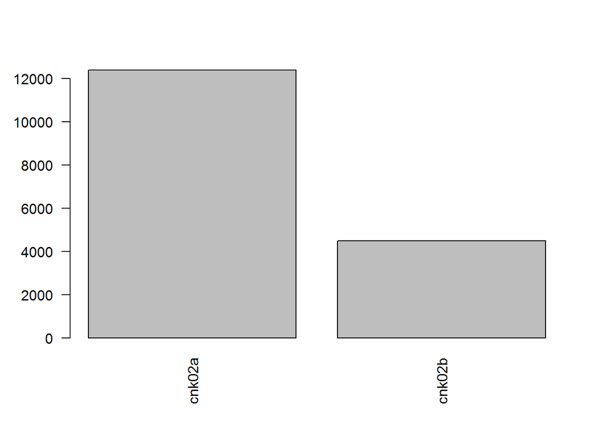

```r
WeeksDays <- c("Sun", "Mon", "Tue", "Wed", "Thu", "Fri", "Sat")

station_count = finalData %>%
  group_by(Station) %>%
  summarise(
    s_count = n()
  )
x = station_count$s_count
names(x) <- station_count$Station
barplot(x, las=2)
```

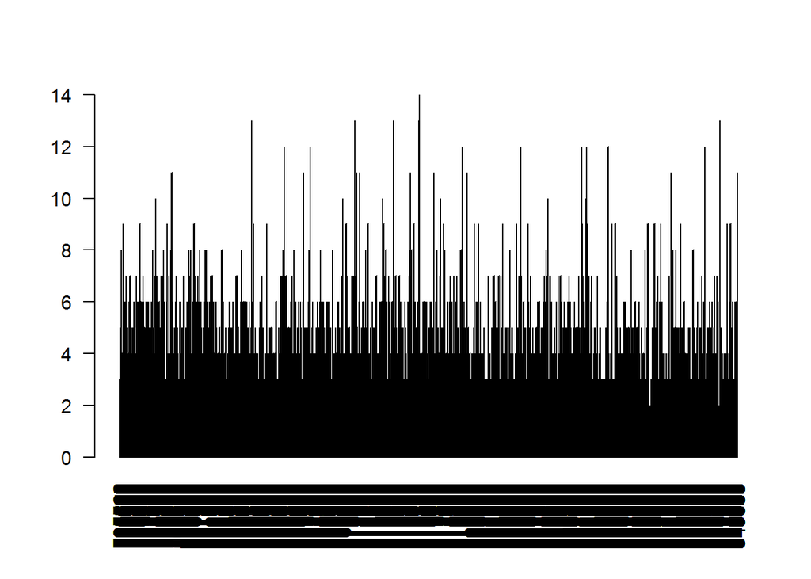

```r
visitor_count = finalData %>%
  group_by(Visitor) %>%
  summarise(
    s_count = n()
  )
x = visitor_count$s_count
names(x) <- visitor_count$Visitor
barplot(x, las=2)
```

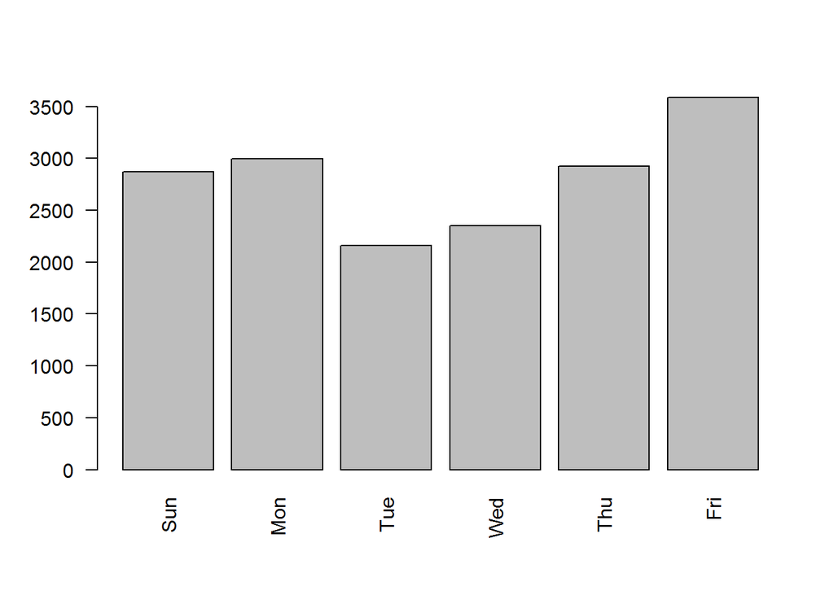

```r
days_count = finalData %>%
  group_by(WDay) %>%
  summarise(
    s_count = n()
  )
x = days_count$s_count
names(x) <- WeeksDays[days_count$WDay]
barplot(x, las=2)
```

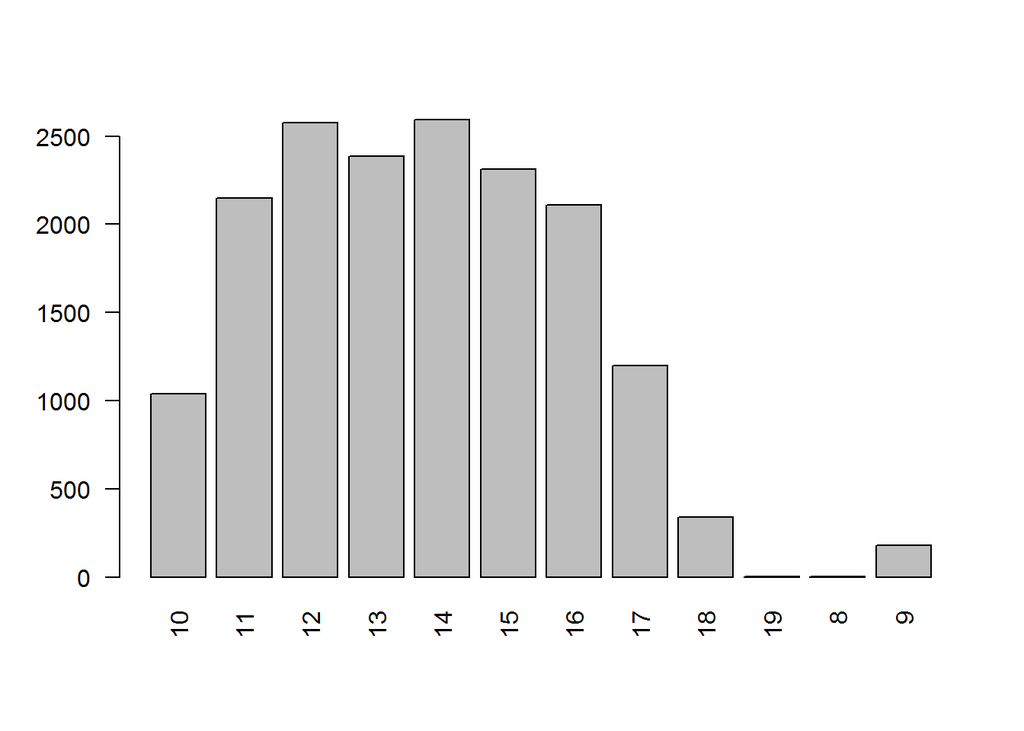

```r
hours_count = finalData %>%
  group_by(THour) %>%
  summarise(
    s_count = n()
  )
x = hours_count$s_count
names(x) <- hours_count$THour
barplot(x, las=2)
```

## Consumed Time During Stations Interactions

in this plot we will see the consumed time for each visitor in specific visit and station.

[figure not shown]

```r
ggplot(finalData, aes(Visitor, Cons_time, color=Station)) +
  geom_point() +
  theme_bw() + theme(axis.text.x=element_text(angle=90,hjust=1,vjust=0.5))
```

```r
station_count = finalData %>%
  group_by(Station) %>%
  summarise(
    s_count = n(),
    s_sum = sum(Cons_time),
    s_avg = mean(Cons_time)
  )
station_count
```

```
## Source: local data frame [2 x 4]
##
##   Station s_count   s_sum    s_avg
##    (fctr)   (int)   (dbl)    (dbl)
## 1  cnk02a   12392 2779820 224.3238
## 2  cnk02b    4495 1022984 227.5826
```

## Consumed time In Each Day

this plot shows the average consumed time in each day in this dataset

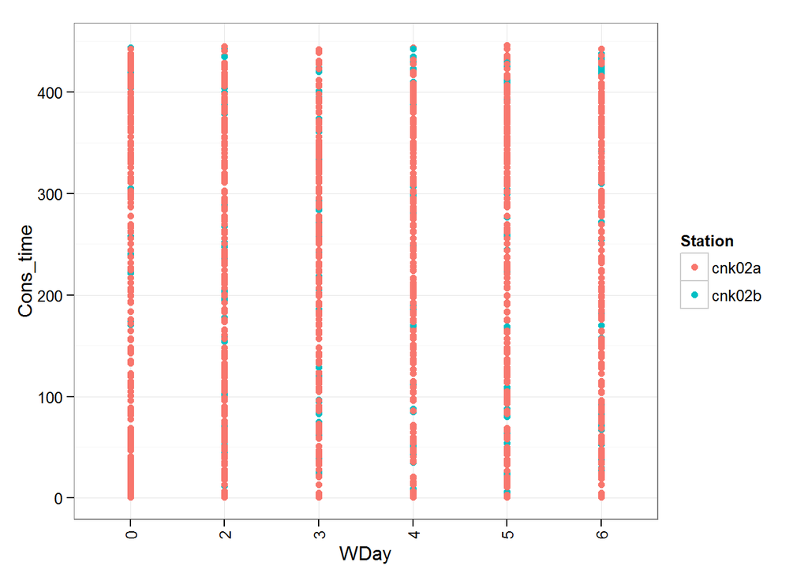

```r
ggplot(finalData, aes(WDay, Cons_time, color=Station)) +
  geom_point() +
  theme_bw() + theme(axis.text.x=element_text(angle=90,hjust=1,vjust=0.5))
```

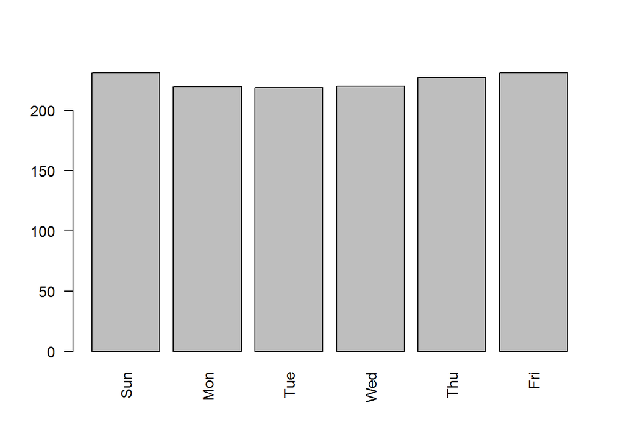

```r
days_count = finalData %>%
  group_by(WDay) %>%
  summarise(
    s_count = n(),
    s_sum = sum(Cons_time),
    s_avg = mean(Cons_time)
  )
x = days_count$s_avg
names(x) <- WeeksDays[days_count$WDay]
barplot(x, las=2)
```

## Average Consumed time In Each Hour

this plot shows the average consumed time in each Hour in this dataset

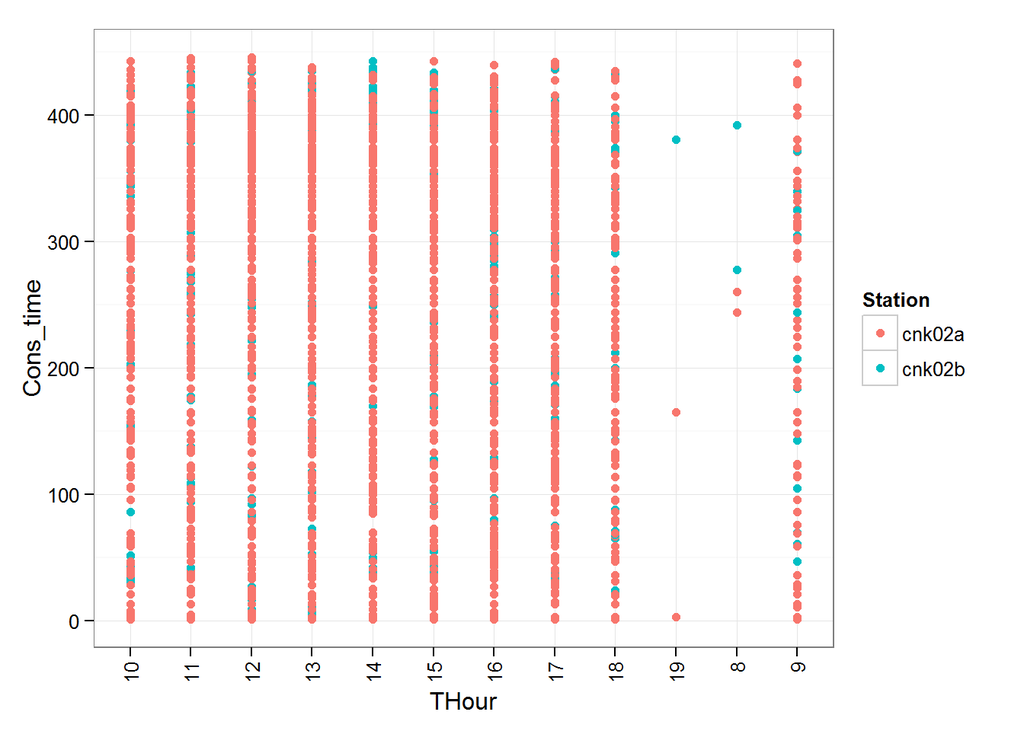

```r
ggplot(finalData, aes(THour, Cons_time, color=Station)) +
  geom_point() +
  theme_bw() + theme(axis.text.x=element_text(angle=90,hjust=1,vjust=0.5))
```

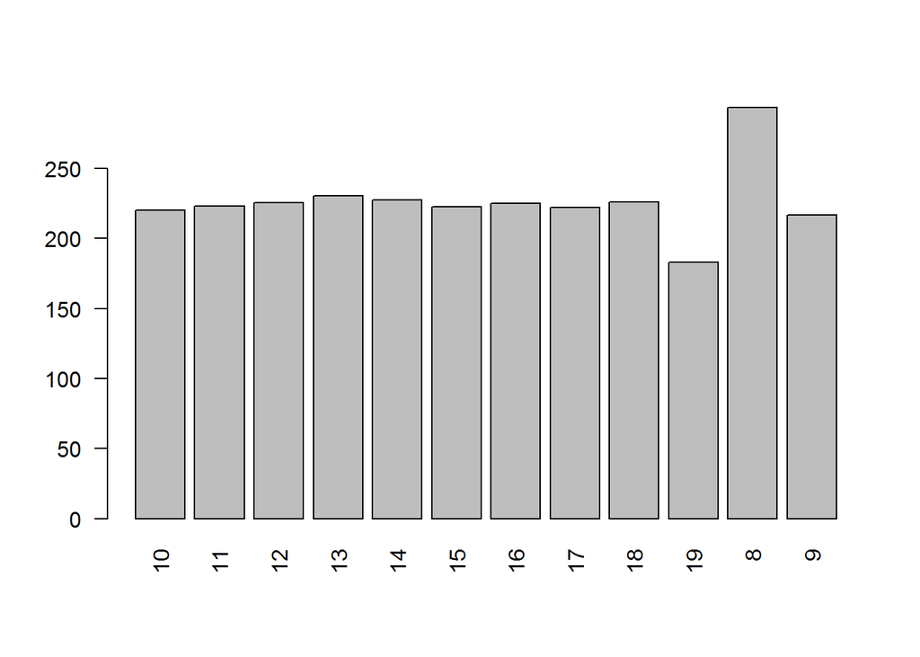

```r
hours_count = finalData %>%
  group_by(THour) %>%
  summarise(
    s_count = n(),
    s_sum = sum(Cons_time),
    s_avg = mean(Cons_time)
  )
x = hours_count$s_avg
names(x) <- hours_count$THour
barplot(x, las=2)
```

## Distinct Visitors In Each Day

this plot shows the count of distinct visitors in each day in this dataset

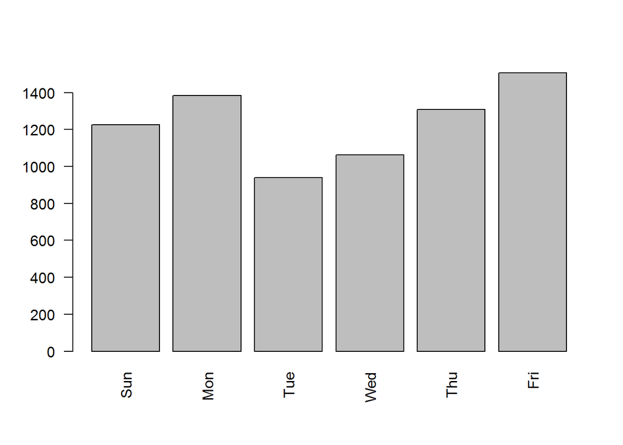

```r
visitor_count = finalData %>%
  group_by(WDay) %>%
  summarise(
    s_count = length(unique(Visitor))
  )
x = visitor_count$s_count
names(x) <- WeeksDays[visitor_count$WDay]
barplot(x, las=2)
```

## Distinct Visitors In Each Hour

The same as the previous plot but in each hour

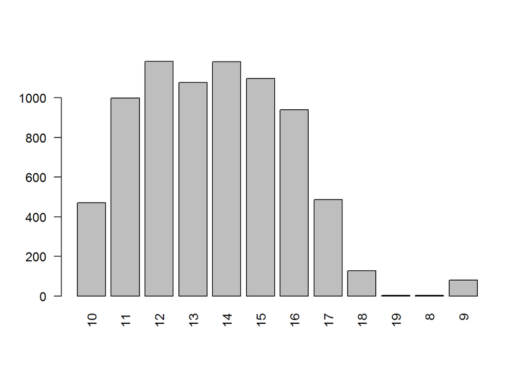

```r
visitor_count = finalData %>%
  group_by(THour) %>%
  summarise(
    s_count = length(unique(Visitor))
  )
x = visitor_count$s_count
names(x) <- visitor_count$THour
barplot(x, las=2)
```

## Average Consumed Time in Each Hour in Each Day

Here we try to go more deep in these statistics , so we tried to find the consumed time for each hour in each day

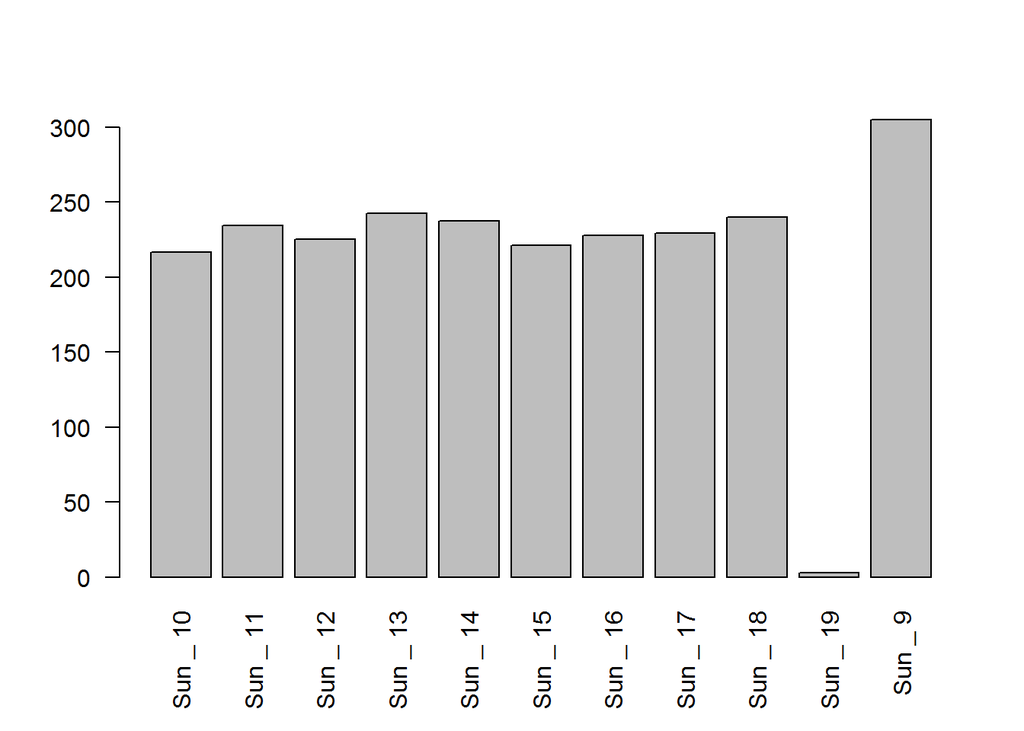

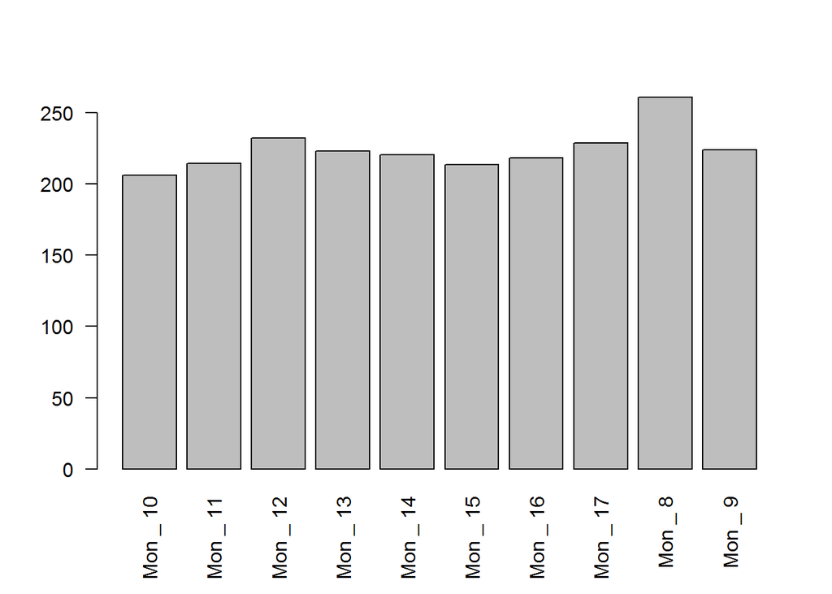

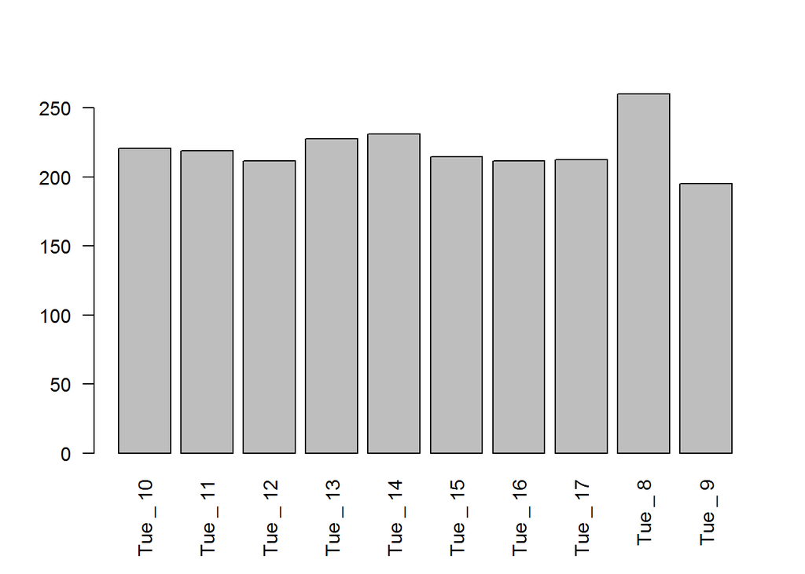

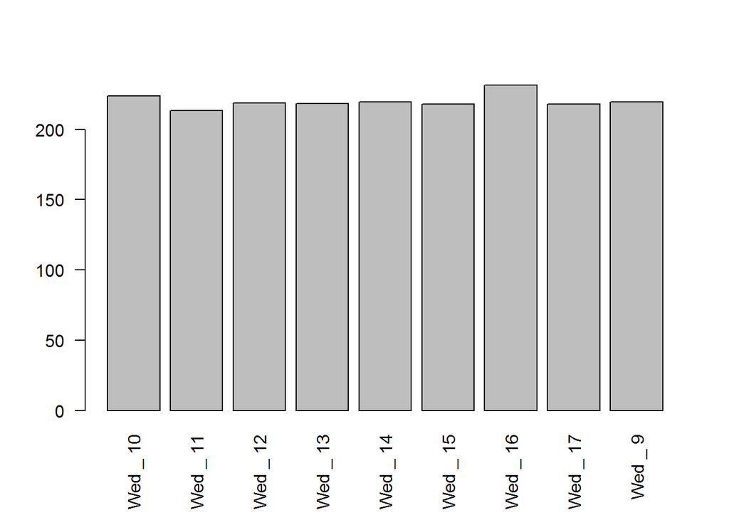

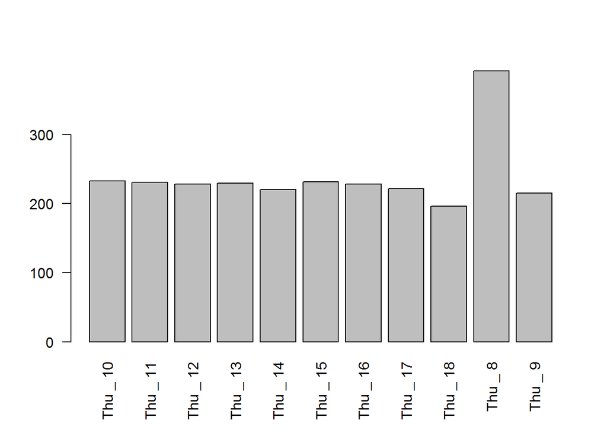

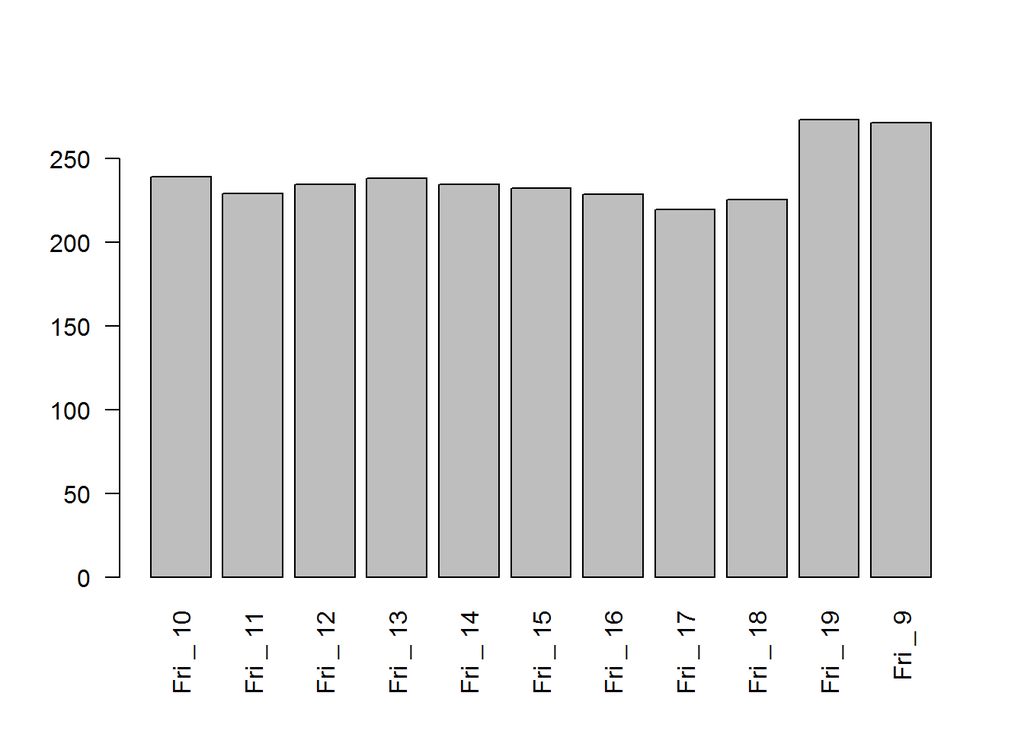

```r
time_d_h = finalData %>%
  group_by(WDay, THour) %>%
  summarise(
    s_count = n(),
    s_sum = sum(Cons_time),
    s_avg = mean(Cons_time)
  )
lst <- unique(time_d_h$WDay)
for (d in 1:length(lst) )
{
  temp <- time_d_h[time_d_h$WDay == lst[d],]
  x = temp$s_avg
  names(x) <- paste(WeeksDays[temp$WDay], '_', temp$THour)
  barplot(x, las=2)

}
```

## Distinct Visitors in Each Hour in Each Day

The same as the previous plot, but for Distinct visitors

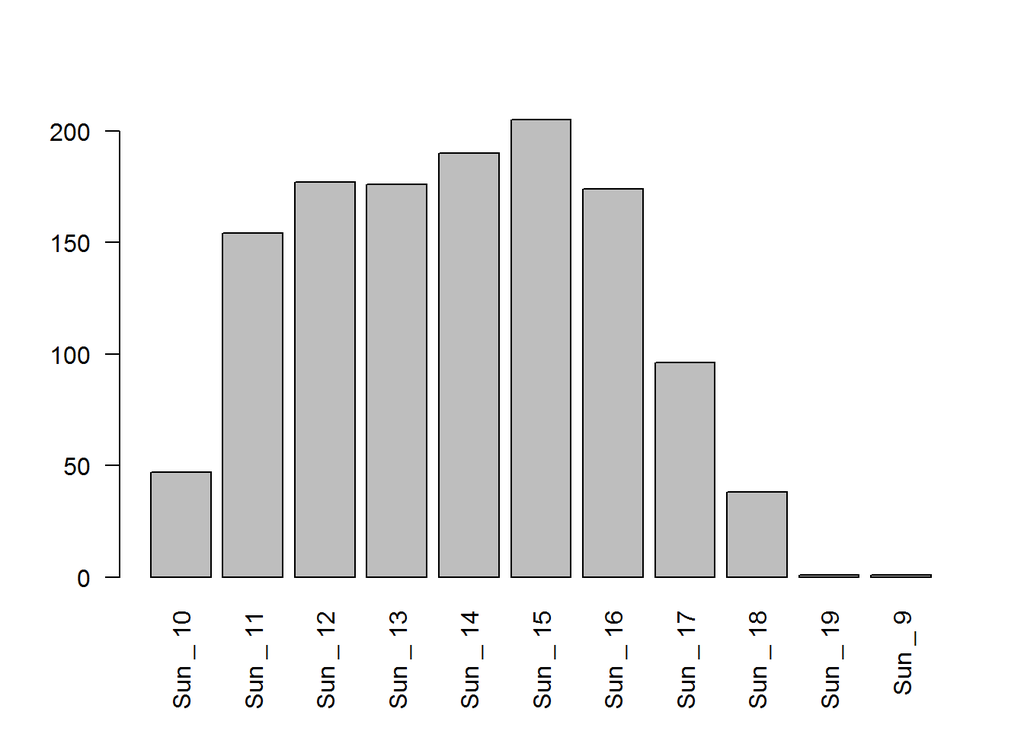

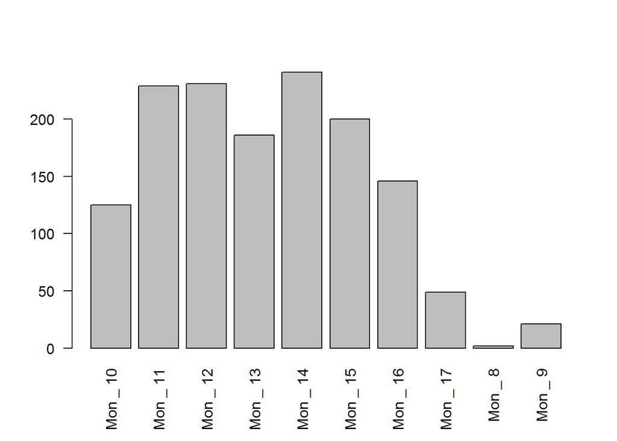

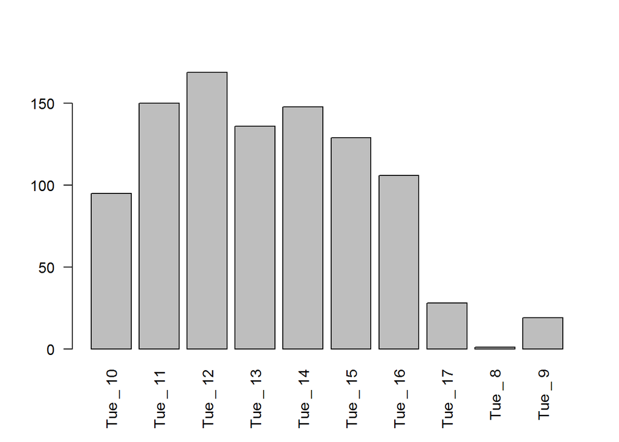

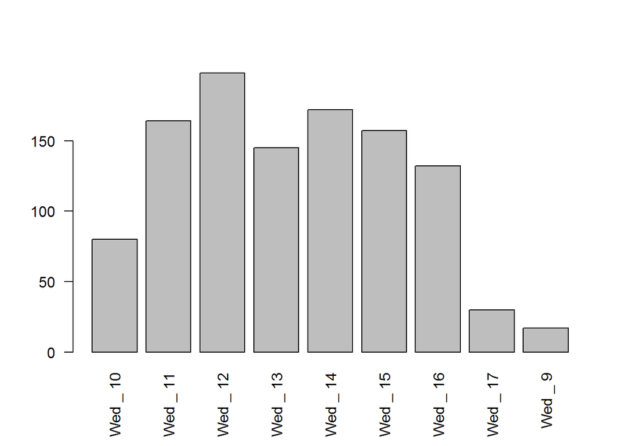

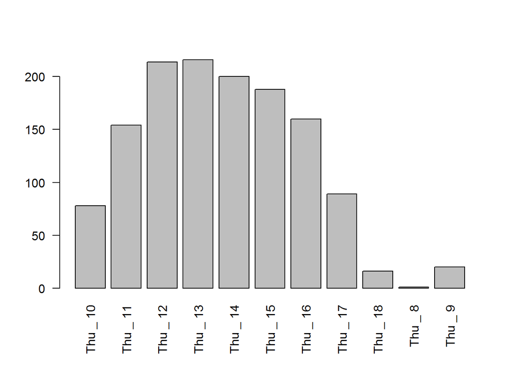

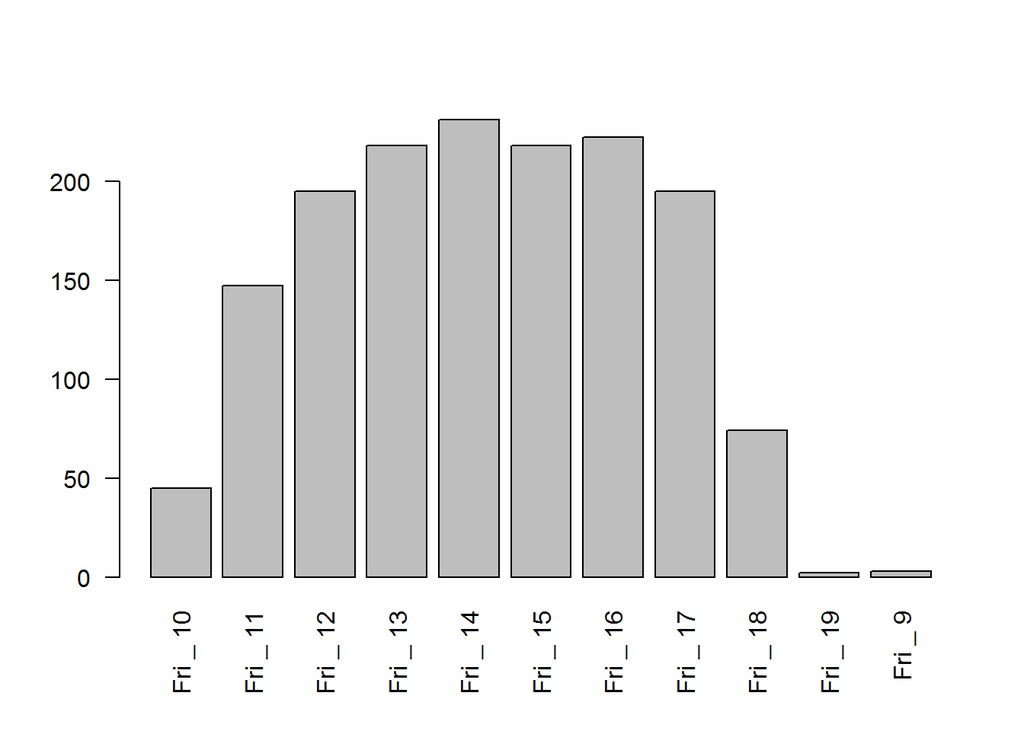

```r
visitor_d_h = finalData %>%
  group_by(WDay, THour) %>%
  summarise(
    s_count = length(unique(Visitor))
  )
lst <- unique(visitor_d_h$WDay)
for (d in 1:length(lst) )
{
  temp <- visitor_d_h[visitor_d_h$WDay == lst[d],]
  x = temp$s_count
  names(x) <- paste(WeeksDays[temp$WDay], '_', temp$THour)
  barplot(x, las=2)

}
```

# Remarks and Conclusion

In this task we applied this strategy, findg all needed data in one dataset, using dplyr library to group the data and get retrieve all needed information to visualize, that makes our task easier.  
for the results, we believe these plots show the most important information we got from this dataset